# CA1 Part A

#### Importing Libraries

```python
import os
import random
from collections import Counter
import numpy as np
import pandas as pd
from PIL import Image
import pathlib
import scipy.ndimage
import matplotlib.pyplot as plt
from sklearn.metrics import classification_report
from sklearn.utils import shuffle
import tensorflow as tf
import keras
from tensorflow.keras import regularizers
from tensorflow.keras import layers, models, optimizers
from tensorflow.keras.models import Sequential
from tensorflow.keras.layers import Conv2D, MaxPooling2D, Flatten, Dense, Dropout, BatchNormalization, Rescaling, GlobalAveragePooling2D
from tensorflow.keras.callbacks import ModelCheckpoint, ReduceLROnPlateau
from tensorflow.keras.preprocessing.image import ImageDataGenerator
from tensorflow.keras.utils import to_categorical
```

```python
import tensorflow as tf
gpus = tf.config.experimental.list_physical_devices('GPU')
for gpu in gpus:
  tf.config.experimental.set_memory_growth(gpu, True)
```

```python
tf.config.list_physical_devices('GPU')
```

```
[PhysicalDevice(name='/physical_device:GPU:0', device_type='GPU')]
```

```python
tf.keras.backend.clear_session()
```

```python
seed = 42
np.random.seed(seed)
keras.utils.set_random_seed(seed)
tf.random.set_seed(seed)
```

## Data Analysis

```python
data_dir = pathlib.Path("./CA1-Part_A-Dataset/Dataset for CA1 part A - AY2526S1")
train_dir = data_dir / "train"
val_dir = data_dir / "validation"
test_dir = data_dir / "test"

batch_size = 32

ds_train = tf.keras.preprocessing.image_dataset_from_directory(
    train_dir,
    batch_size=batch_size
)

ds_test = tf.keras.preprocessing.image_dataset_from_directory(
    test_dir,
    batch_size=batch_size
)

ds_val = tf.keras.preprocessing.image_dataset_from_directory(
    val_dir,
    batch_size=batch_size
)
```

```
Found 7695 files belonging to 11 classes.
Found 2200 files belonging to 11 classes.
Found 2200 files belonging to 11 classes.
```

```python
def preprocess_and_resize(ds, size):
    return ds.map(lambda x, y: (tf.image.resize(tf.image.rgb_to_grayscale(x), size), y))
```

```python
ds_train_23 = preprocess_and_resize(ds_train, (23, 23))
ds_test_23 = preprocess_and_resize(ds_test, (23, 23))
ds_val_23 = preprocess_and_resize(ds_val, (23, 23))

ds_train_101 = preprocess_and_resize(ds_train, (101, 101))
ds_test_101 = preprocess_and_resize(ds_test, (101, 101))
ds_val_101 = preprocess_and_resize(ds_val, (101, 101))

class_names = ds_train.class_names

print(class_names)
```

```
['Bean', 'Bitter_Gourd', 'Brinjal', 'Cabbage', 'Capsicum', 'Carrot and Radish', 'Cauliflower and Broccoli', 'Cucumber and Bottle_Gourd', 'Potato', 'Pumpkin', 'Tomato']
```

#### Before we start training the model, we can take a look at the images

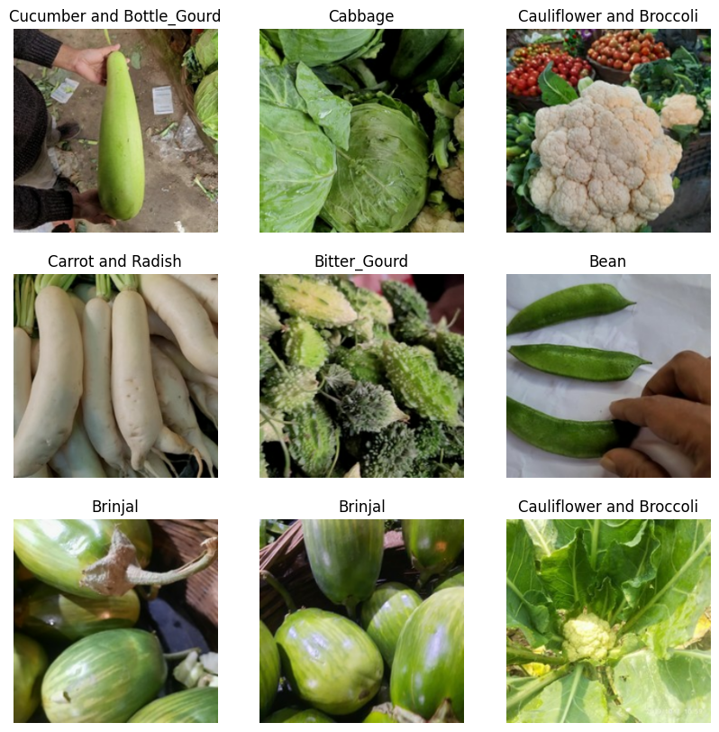

```python
import matplotlib.pyplot as plt

plt.figure(figsize=(10, 10))
for images, labels in ds_train.take(1):
  for i in range(9):
    ax = plt.subplot(3, 3, i + 1)
    plt.imshow(images[i].numpy().astype("uint8"))
    plt.title(class_names[labels[i]])
    plt.axis("off")
```

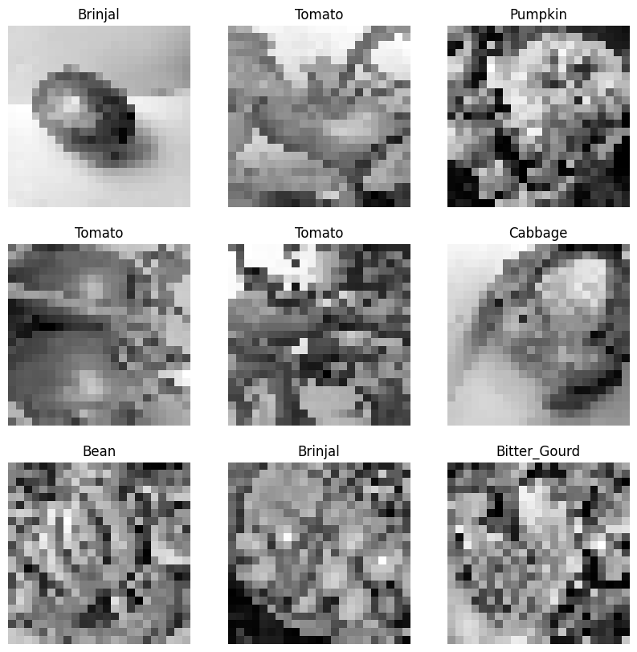

```python
import matplotlib.pyplot as plt

plt.figure(figsize=(10, 10))
for images, labels in ds_train_23.take(1):
  for i in range(9):
    ax = plt.subplot(3, 3, i + 1)
    plt.imshow(images[i].numpy().astype("uint8"), cmap='gray')
    plt.title(class_names[labels[i]])
    plt.axis("off")
```

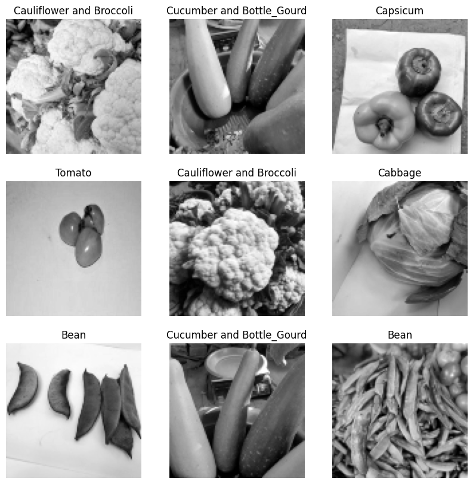

```python
import matplotlib.pyplot as plt

plt.figure(figsize=(10, 10))
for images, labels in ds_train_101.take(1):
  for i in range(9):
    ax = plt.subplot(3, 3, i + 1)
    plt.imshow(images[i].numpy().astype("uint8"), cmap='gray')
    plt.title(class_names[labels[i]])
    plt.axis("off")
```

We can see that the images with 101 by 101 pixels has much more clarity and are much more discernable compared to the images with 23 by 23 pixels

## Exploratory Data Analysis

### Class Imbalance

```python
class_names = ds_train.class_names
```

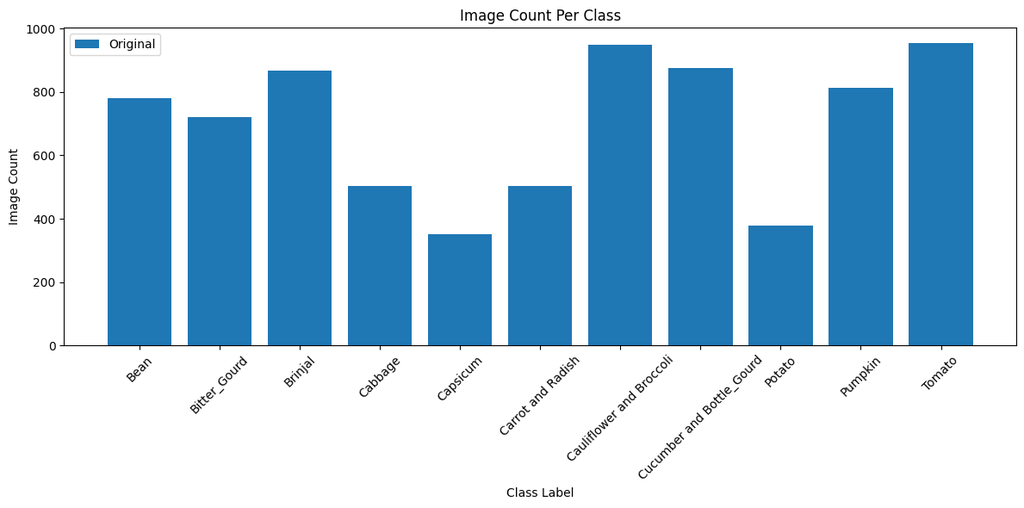

```python
label_names = []
for _, label in ds_train:
    label_names.extend(label.numpy())
counts = Counter(label_names)
labels = sorted(counts.keys())
original_values = [counts[label] for label in labels]
class_labels = [class_names[label] for label in labels]

x = np.arange(len(labels))

plt.figure(figsize=(12, 6))
plt.bar(x , original_values, label='Original')
plt.xlabel('Class Label')
plt.ylabel('Image Count')
plt.title('Image Count Per Class')
plt.xticks(x, class_labels, rotation=45)
plt.legend()
plt.tight_layout()
plt.show()
```

#### Observations:

- From the chart, we can see that the number of images for each vegetable is not balanced with some having as many as 900 images and others having much less, such as Capsicum with only around 350 images
- As such, we must find a way to handle this later during model training

### Image Pixel Distribution

```python
all_images_23 = []
for img, _ in ds_train_23:
    all_images_23.append(img.numpy())

train_23_imgs = np.vstack(all_images_23)

print("23x23 Images")
print("Mean: ", np.mean(train_23_imgs))
print("Stdev: ", np.std(train_23_imgs))


print('\n')

all_images_101 = []
for img, _ in ds_train_101:
    all_images_101.append(img.numpy())

train_101_imgs = np.vstack(all_images_101)

print("101x101 Images")
print("Mean: ", np.mean(train_101_imgs))
print("Stdev: ", np.std(train_101_imgs))
```

```
23x23 Images
Mean:  115.01708
Stdev:  55.384373


101x101 Images
Mean:  115.007645
Stdev:  55.400948
```

From the mean pixel value, we see that the average pixel is not very bright but there is some variation in the pixel intensity for both 23 by 23 and 101 by 101 images

### Image Averaging

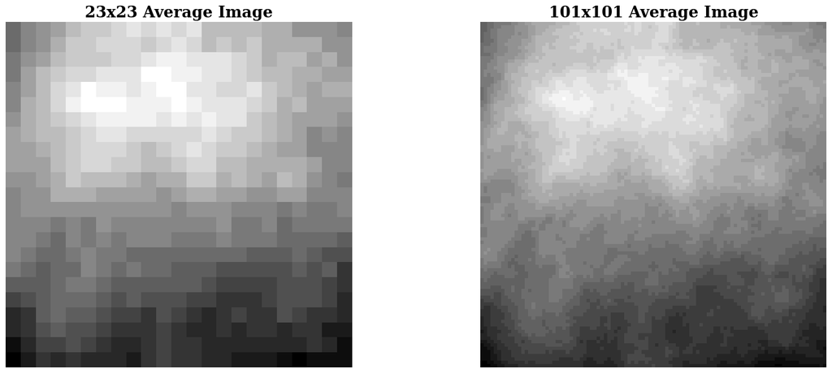

```python
fig, ax = plt.subplots(1, 2, figsize=(20, 8))

ax[0].set_title("23x23 Average Image", fontfamily='serif', fontsize=20, fontweight='bold')
ax[0].imshow(np.mean(train_23_imgs, axis=0).astype('uint16'), cmap='gray')
ax[0].axis('off')

ax[1].set_title("101x101 Average Image", fontfamily='serif', fontsize=20, fontweight='bold')
ax[1].imshow(np.mean(train_101_imgs, axis=0).astype('uint16'), cmap='gray')
ax[1].axis('off')

plt.show()
```

### Observations:

- From both images we can see that generally, the brighter pixels are on top and not exactly in the middle. This means that many of the images are not all zoomed in so that the entire image only contains the specific vegetable
- It seems that although the 23x23 image is not as clear compared to the 101x101 image, there are still some similar features which can be discerned when comparing the two images

Next, we will see what is the average image for each class label to see how similar each image is

```python
def plot_avg_images(dataset, class_names, n_rows=3, n_cols=5, cmap='gray', title=""):
    images = []
    labels = []
    for batch_images, batch_labels in dataset.unbatch():
        images.append(batch_images.numpy())
        labels.append(batch_labels.numpy())

    X = np.stack(images)
    y = np.array(labels)

    fig, ax = plt.subplots(n_rows, n_cols, figsize=(24, 10))
    plt.suptitle(title, fontfamily='serif', fontsize=20, fontweight='bold')

    for idx, subplot in enumerate(ax.ravel()):
        if idx >= len(class_names):
            subplot.axis('off')
            continue

        class_mask = y == idx
        class_images = X[class_mask]

        if len(class_images) > 0:
            avg_image = np.mean(class_images, axis=0)
            subplot.imshow(avg_image, cmap=cmap)
            subplot.set_title(class_names[idx], fontfamily='serif', fontsize=12, fontweight='bold')
            subplot.axis('off')
        else:
            subplot.axis('off')
```

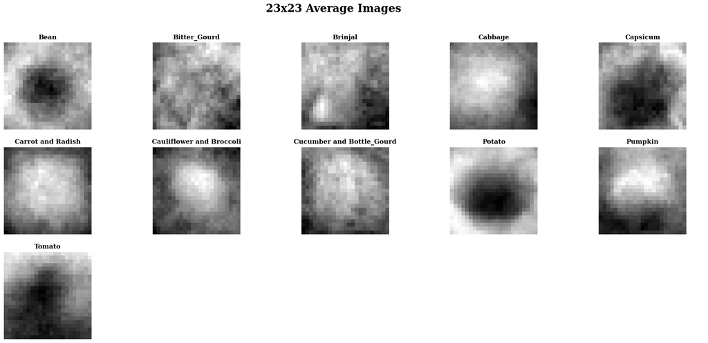

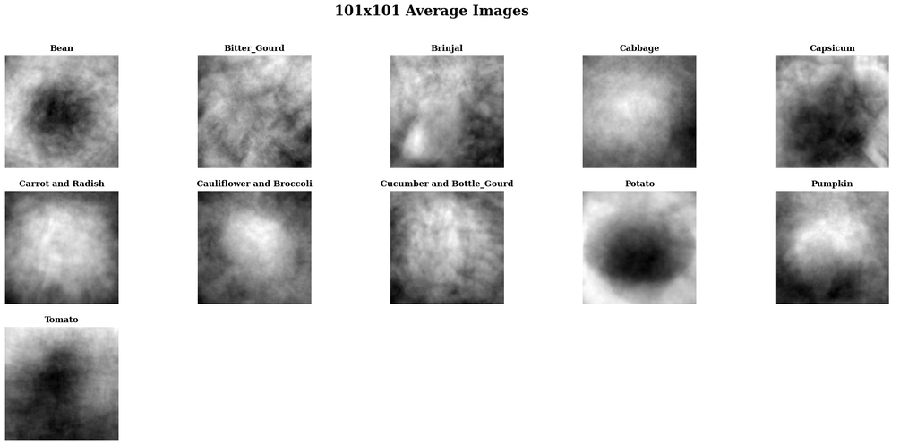

```python
plot_avg_images(ds_train_23, class_names=class_names, title="23x23 Average Images")
plot_avg_images(ds_train_101, class_names=class_names, title="101x101 Average Images")
```

## 23 x 23

### Baseline for 23x23 (Original)

```python
X_batches, y_batches = zip(*ds_train_23.as_numpy_iterator())
X_train = np.vstack(X_batches)
y_train = np.hstack(y_batches)

X_train_23 = X_train.astype('float32') / 255.0
y_train_23 = to_categorical(y_train)

print("X_train shape:", X_train_23.shape)
print("y_train shape:", y_train_23.shape)
```

```
X_train shape: (7695, 23, 23, 1)
y_train shape: (7695, 11)
```

```python
X_batches, y_batches = zip(*ds_val_23.as_numpy_iterator())

X_val = np.vstack(X_batches)
y_val = np.hstack(y_batches)

X_val_23 = X_val.astype('float32') / 255.0

y_val_23 = to_categorical(y_val)

print("X_val shape:", X_val_23.shape)
print("y_val shape:", y_val_23.shape)
```

```
X_val shape: (2200, 23, 23, 1)
y_val shape: (2200, 11)
```

```python
X_batches, y_batches = zip(*ds_test_23.as_numpy_iterator())

X_test = np.vstack(X_batches)
y_test = np.hstack(y_batches)

X_test_23 = X_test.astype('float32') / 255.0

y_test_23 = to_categorical(y_test)

print("X_test shape:", X_test_23.shape)
print("y_test shape:", y_test_23.shape)
```

```
X_test shape: (2200, 23, 23, 1)
y_test shape: (2200, 11)
```

```python
num_classes = y_test_23.shape[1]
```

```python
OriginalModel23 = Sequential([
    Conv2D(64, (3, 3), padding='same', activation='relu', input_shape=(23, 23, 1), kernel_regularizer=regularizers.l2(0.001)),
    BatchNormalization(),
    MaxPooling2D(pool_size=2),

    Conv2D(128, (3, 3), padding='same', activation='relu', kernel_regularizer=regularizers.l2(0.001)),
    BatchNormalization(),
    MaxPooling2D(pool_size=2),

    Flatten(),
    Dropout(0.5),

    Dense(64, activation='relu', kernel_regularizer=regularizers.l2(0.001)),
    BatchNormalization(),
    Dense(num_classes, activation='softmax')
])

OriginalModel23.compile(loss='categorical_crossentropy', optimizer='adam', metrics=['accuracy'])

checkpoint = ModelCheckpoint('./Part A checkpoints/original_model_weights_23.h5', monitor='val_accuracy', save_best_only=True, save_weights_only=True, mode='max', verbose=1)

history = OriginalModel23.fit(X_train_23, y_train_23, validation_data=(X_val_23, y_val_23), epochs=100, batch_size=32, callbacks=[checkpoint], verbose=1)

OriginalModel23.summary()
```

```
Epoch 1: val_accuracy improved from -inf to 0.13045, saving model to ./Part A checkpoints\original_model_weights_23.h5
Epoch 2: val_accuracy improved from 0.13045 to 0.24955, saving model to ./Part A checkpoints\original_model_weights_23.h5
Epoch 3: val_accuracy improved from 0.24955 to 0.63000, saving model to ./Part A checkpoints\original_model_weights_23.h5
Epoch 4: val_accuracy improved from 0.63000 to 0.74136, saving model to ./Part A checkpoints\original_model_weights_23.h5
Epoch 5: val_accuracy improved from 0.74136 to 0.78727, saving model to ./Part A checkpoints\original_model_weights_23.h5
Epoch 6: val_accuracy did not improve from 0.78727
Epoch 7: val_accuracy did not improve from 0.78727
Epoch 8: val_accuracy did not improve from 0.78727
Epoch 9: val_accuracy did not improve from 0.78727
Epoch 10: val_accuracy improved from 0.78727 to 0.84682, saving model to ./Part A checkpoints\original_model_weights_23.h5
Epoch 11: val_accuracy did not improve from 0.84682
Epoch 12: val_accuracy did not improve from 0.84682
Epoch 13: val_accuracy did not improve from 0.84682
Epoch 14: val_accuracy did not improve from 0.84682
Epoch 15: val_accuracy did not improve from 0.84682
Epoch 16: val_accuracy did not improve from 0.84682
Epoch 17: val_accuracy did not improve from 0.84682
Epoch 18: val_accuracy did not improve from 0.84682
Epoch 19: val_accuracy did not improve from 0.84682
Epoch 20: val_accuracy did not improve from 0.84682
Epoch 21: val_accuracy did not improve from 0.84682
Epoch 22: val_accuracy did not improve from 0.84682
Epoch 23: val_accuracy did not improve from 0.84682
Epoch 24: val_accuracy improved from 0.84682 to 0.85682, saving model to ./Part A checkpoints\original_model_weights_23.h5
Epoch 25: val_accuracy did not improve from 0.85682
Epoch 26: val_accuracy did not improve from 0.85682
Epoch 27: val_accuracy did not improve from 0.85682
Epoch 28: val_accuracy did not improve from 0.85682
Epoch 29: val_accuracy did not improve from 0.85682
Epoch 30: val_accuracy did not improve from 0.85682
Epoch 31: val_accuracy did not improve from 0.85682
Epoch 32: val_accuracy did not improve from 0.85682
Epoch 33: val_accuracy did not improve from 0.85682
Epoch 34: val_accuracy did not improve from 0.85682
Epoch 35: val_accuracy did not improve from 0.85682
Epoch 36: val_accuracy did not improve from 0.85682
Epoch 37: val_accuracy improved from 0.85682 to 0.85818, saving model to ./Part A checkpoints\original_model_weights_23.h5
Epoch 38: val_accuracy did not improve from 0.85818
Epoch 39: val_accuracy did not improve from 0.85818
Epoch 40: val_accuracy did not improve from 0.85818
```

[output cut: 81 more lines]

```

 dropout (Dropout)           (None, 3200)              0

 dense (Dense)               (None, 64)                204864

 batch_normalization_2 (Batc  (None, 64)               256
 hNormalization)

 dense_1 (Dense)             (None, 11)                715

=================================================================
Total params: 281,099
Trainable params: 280,587
Non-trainable params: 512
_________________________________________________________________
```

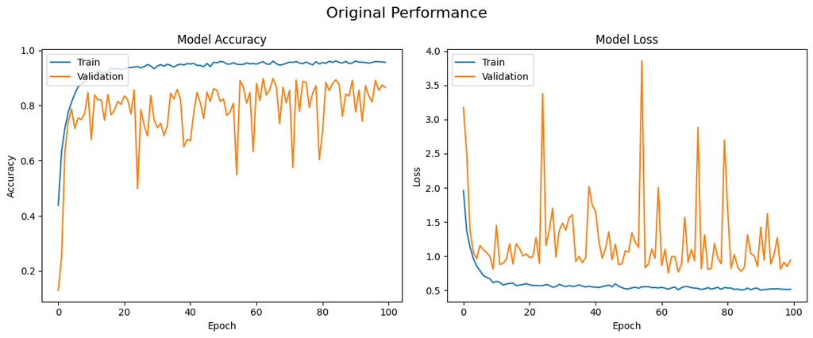

```python
fig, axs = plt.subplots(1, 2, figsize=(12, 5))

fig.suptitle('Original Performance', fontsize=16)

axs[0].plot(history.history['accuracy'])
axs[0].plot(history.history['val_accuracy'])
axs[0].set_title('Model Accuracy')
axs[0].set_ylabel('Accuracy')
axs[0].set_xlabel('Epoch')
axs[0].legend(['Train', 'Validation'], loc='upper left')

axs[1].plot(history.history['loss'])
axs[1].plot(history.history['val_loss'])
axs[1].set_title('Model Loss')
axs[1].set_ylabel('Loss')
axs[1].set_xlabel('Epoch')
axs[1].legend(['Train', 'Validation'], loc='upper left')

plt.tight_layout()
plt.show()
```

#### Observations:

- The graphs are quite noisy
- The validation accuracy seems acceptable while validation loss seems high (above 1.0)

```python
perf_23_models = pd.DataFrame()
```

```python
model_name = "Original"

model_hist = {
    "Mean loss": np.mean(history.history['loss']),
    "Mean accuracy": np.mean(history.history['accuracy']),
    "Mean val_loss": np.mean(history.history['val_loss']),
    "Mean val_accuracy": np.mean(history.history['val_accuracy']),
}

model_df = pd.DataFrame([model_hist], index=[model_name])

perf_23_models = pd.concat([perf_23_models, model_df])

display(perf_23_models)
```

|  | Mean loss | Mean accuracy | Mean val_loss | Mean val_accuracy |
| --- | --- | --- | --- | --- |
| Original | 0.592896 | 0.930233 | 1.224521 | 0.784536 |

### Balanced Data Augmentation

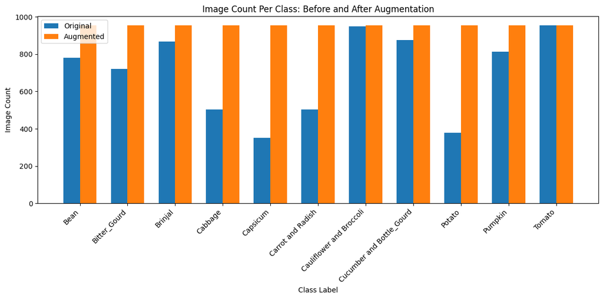

```python
X_batches, y_batches = zip(*ds_train_23.as_numpy_iterator())

X_train = np.vstack(X_batches)
y_train = np.hstack(y_batches)

X_train = X_train.astype('float32') / 255.0

class_counts = Counter(y_train)
max_count = max(class_counts.values())

datagen = ImageDataGenerator(
    rotation_range=10,
    width_shift_range=0.1,
    height_shift_range=0.1,
    zoom_range=0.1
)

X_balanced = []
y_balanced = []

for label in class_counts:
    idx = np.where(y_train == label)[0]
    X_class = X_train[idx]
    y_class = y_train[idx]

    X_balanced.extend(X_class)
    y_balanced.extend(y_class)

    num_to_generate = max_count - len(idx)
    if num_to_generate > 0:

        aug_iter = datagen.flow(X_class, y_class, batch_size=1)
        for _ in range(num_to_generate):
            x_aug, y_aug = next(aug_iter)
            X_balanced.append(x_aug[0])
            y_balanced.append(y_aug[0])

X_train_balanced_23 = np.array(X_balanced)
y_train_balanced_23 = to_categorical(np.array(y_balanced))

class_names = ds_train.class_names
original_counts = Counter(y_train)
augmented_counts = Counter(np.argmax(y_train_balanced_23, axis=1))

labels = sorted(original_counts.keys())
original_values = [original_counts[label] for label in labels]
augmented_values = [augmented_counts[label] for label in labels]

x = np.arange(len(labels))
width = 0.35

plt.figure(figsize=(12, 6))
plt.bar(x - width/2, original_values, width, label='Original')
plt.bar(x + width/2, augmented_values, width, label='Augmented')
plt.xlabel('Class Label')
plt.ylabel('Image Count')
plt.title('Image Count Per Class: Before and After Augmentation')
plt.xticks(x, class_names, rotation=45, ha='right')
plt.legend()
plt.tight_layout()
plt.show()
```

```python
print("Balanced X shape:", X_train_balanced_23.shape)
print("Balanced y shape:", y_train_balanced_23.shape)
```

```
Balanced X shape: (10505, 23, 23, 1)
Balanced y shape: (10505, 11)
```

```python
AugmentedModel23 = Sequential([
    Conv2D(64, (3, 3), padding='same', activation='relu', input_shape=(23, 23, 1), kernel_regularizer=regularizers.l2(0.001)),
    BatchNormalization(),
    MaxPooling2D(pool_size=2),

    Conv2D(128, (3, 3), padding='same', activation='relu', kernel_regularizer=regularizers.l2(0.001)),
    BatchNormalization(),
    MaxPooling2D(pool_size=2),

    Flatten(),
    Dropout(0.5),

    Dense(64, activation='relu', kernel_regularizer=regularizers.l2(0.001)),
    BatchNormalization(),
    Dense(num_classes, activation='softmax')
])

AugmentedModel23.compile(loss='categorical_crossentropy', optimizer='adam', metrics=['accuracy'])

checkpoint = ModelCheckpoint('./Part A checkpoints/augmented_model_weights_23.h5', monitor='val_accuracy', save_best_only=True, save_weights_only=True, mode='max', verbose=1)

history = AugmentedModel23.fit(X_train_balanced_23, y_train_balanced_23, validation_data=(X_val_23, y_val_23), epochs=100, batch_size=32, callbacks=[checkpoint], verbose=1)

AugmentedModel23.summary()
```

```
Epoch 1: val_accuracy improved from -inf to 0.14864, saving model to ./Part A checkpoints\augmented_model_weights_23.h5
Epoch 2: val_accuracy improved from 0.14864 to 0.66273, saving model to ./Part A checkpoints\augmented_model_weights_23.h5
Epoch 3: val_accuracy improved from 0.66273 to 0.73182, saving model to ./Part A checkpoints\augmented_model_weights_23.h5
Epoch 4: val_accuracy did not improve from 0.73182
Epoch 5: val_accuracy did not improve from 0.73182
Epoch 6: val_accuracy improved from 0.73182 to 0.78818, saving model to ./Part A checkpoints\augmented_model_weights_23.h5
Epoch 7: val_accuracy did not improve from 0.78818
Epoch 8: val_accuracy improved from 0.78818 to 0.79409, saving model to ./Part A checkpoints\augmented_model_weights_23.h5
Epoch 9: val_accuracy improved from 0.79409 to 0.86500, saving model to ./Part A checkpoints\augmented_model_weights_23.h5
Epoch 10: val_accuracy did not improve from 0.86500
Epoch 11: val_accuracy did not improve from 0.86500
Epoch 12: val_accuracy did not improve from 0.86500
Epoch 13: val_accuracy did not improve from 0.86500
Epoch 14: val_accuracy did not improve from 0.86500
Epoch 15: val_accuracy did not improve from 0.86500
Epoch 16: val_accuracy did not improve from 0.86500
Epoch 17: val_accuracy did not improve from 0.86500
Epoch 18: val_accuracy did not improve from 0.86500
Epoch 19: val_accuracy did not improve from 0.86500
Epoch 20: val_accuracy did not improve from 0.86500
Epoch 21: val_accuracy did not improve from 0.86500
Epoch 22: val_accuracy did not improve from 0.86500
Epoch 23: val_accuracy did not improve from 0.86500
Epoch 24: val_accuracy did not improve from 0.86500
Epoch 25: val_accuracy did not improve from 0.86500
Epoch 26: val_accuracy did not improve from 0.86500
Epoch 27: val_accuracy did not improve from 0.86500
Epoch 28: val_accuracy did not improve from 0.86500
Epoch 29: val_accuracy improved from 0.86500 to 0.87091, saving model to ./Part A checkpoints\augmented_model_weights_23.h5
Epoch 30: val_accuracy did not improve from 0.87091
Epoch 31: val_accuracy did not improve from 0.87091
Epoch 32: val_accuracy did not improve from 0.87091
Epoch 33: val_accuracy did not improve from 0.87091
Epoch 34: val_accuracy improved from 0.87091 to 0.88409, saving model to ./Part A checkpoints\augmented_model_weights_23.h5
Epoch 35: val_accuracy did not improve from 0.88409
Epoch 36: val_accuracy did not improve from 0.88409
Epoch 37: val_accuracy did not improve from 0.88409
Epoch 38: val_accuracy did not improve from 0.88409
Epoch 39: val_accuracy did not improve from 0.88409
Epoch 40: val_accuracy did not improve from 0.88409
```

[output cut: 81 more lines]

```

 dropout_1 (Dropout)         (None, 3200)              0

 dense_2 (Dense)             (None, 64)                204864

 batch_normalization_5 (Batc  (None, 64)               256
 hNormalization)

 dense_3 (Dense)             (None, 11)                715

=================================================================
Total params: 281,099
Trainable params: 280,587
Non-trainable params: 512
_________________________________________________________________
```

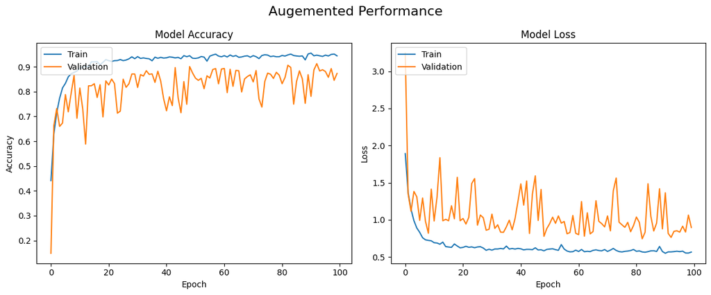

```python
fig, axs = plt.subplots(1, 2, figsize=(12, 5))

fig.suptitle('Augemented Performance', fontsize=16)

axs[0].plot(history.history['accuracy'])
axs[0].plot(history.history['val_accuracy'])
axs[0].set_title('Model Accuracy')
axs[0].set_ylabel('Accuracy')
axs[0].set_xlabel('Epoch')
axs[0].legend(['Train', 'Validation'], loc='upper left')

axs[1].plot(history.history['loss'])
axs[1].plot(history.history['val_loss'])
axs[1].set_title('Model Loss')
axs[1].set_ylabel('Loss')
axs[1].set_xlabel('Epoch')
axs[1].legend(['Train', 'Validation'], loc='upper left')

plt.tight_layout()
plt.show()
```

#### Observations:

- Less noisy, improvement over original
- Could still be improved

```python
model_name = "Augmented"

model_hist = {
    "Mean loss": np.mean(history.history['loss']),
    "Mean accuracy": np.mean(history.history['accuracy']),
    "Mean val_loss": np.mean(history.history['val_loss']),
    "Mean val_accuracy": np.mean(history.history['val_accuracy']),
}

model_df = pd.DataFrame([model_hist], index=[model_name])

perf_23_models = pd.concat([perf_23_models, model_df])

display(perf_23_models)
```

|  | Mean loss | Mean accuracy | Mean val_loss | Mean val_accuracy |
| --- | --- | --- | --- | --- |
| Original | 0.592896 | 0.930233 | 1.224521 | 0.784536 |
| Augmented | 0.641706 | 0.919871 | 1.070786 | 0.818741 |

### Tuned Model

#### Learning Rate Scheduler

```python
reduce_lr = ReduceLROnPlateau(monitor='val_loss', factor=0.5, patience=5, min_lr=1e-6, verbose=1)
```

```python
TunedModel23 = Sequential([
    Conv2D(64, (3, 3), padding='same', activation='relu', input_shape=(23, 23, 1), kernel_regularizer=regularizers.l2(0.001)),
    BatchNormalization(),
    MaxPooling2D(pool_size=2),

    Conv2D(128, (3, 3), padding='same', activation='relu', kernel_regularizer=regularizers.l2(0.001)),
    BatchNormalization(),
    MaxPooling2D(pool_size=2),

    Flatten(),
    Dropout(0.5),

    Dense(64, activation='relu', kernel_regularizer=regularizers.l2(0.001)),
    BatchNormalization(),
    Dense(num_classes, activation='softmax')
])

TunedModel23.compile(loss='categorical_crossentropy', optimizer='adam', metrics=['accuracy'])

checkpoint = ModelCheckpoint('./Part A checkpoints/tuned_model_weights_23.h5', monitor='val_accuracy', save_best_only=True, save_weights_only=True, mode='max', verbose=1)

history = TunedModel23.fit(X_train_balanced_23, y_train_balanced_23, validation_data=(X_val_23, y_val_23), epochs=100, batch_size=32, callbacks=[checkpoint, reduce_lr], verbose=1)

TunedModel23.summary()
```

```
Epoch 1: val_accuracy improved from -inf to 0.17818, saving model to ./Part A checkpoints\tuned_model_weights_23.h5
Epoch 2: val_accuracy improved from 0.17818 to 0.63318, saving model to ./Part A checkpoints\tuned_model_weights_23.h5
Epoch 3: val_accuracy improved from 0.63318 to 0.68909, saving model to ./Part A checkpoints\tuned_model_weights_23.h5
Epoch 4: val_accuracy did not improve from 0.68909
Epoch 5: val_accuracy did not improve from 0.68909
Epoch 6: val_accuracy improved from 0.68909 to 0.82864, saving model to ./Part A checkpoints\tuned_model_weights_23.h5
Epoch 7: val_accuracy did not improve from 0.82864
Epoch 8: val_accuracy did not improve from 0.82864
Epoch 9: val_accuracy did not improve from 0.82864
Epoch 10: val_accuracy did not improve from 0.82864
Epoch 11: val_accuracy did not improve from 0.82864

Epoch 11: ReduceLROnPlateau reducing learning rate to 0.0005000000237487257.
Epoch 12: val_accuracy improved from 0.82864 to 0.84636, saving model to ./Part A checkpoints\tuned_model_weights_23.h5
Epoch 13: val_accuracy improved from 0.84636 to 0.86091, saving model to ./Part A checkpoints\tuned_model_weights_23.h5
Epoch 14: val_accuracy improved from 0.86091 to 0.88864, saving model to ./Part A checkpoints\tuned_model_weights_23.h5
Epoch 15: val_accuracy did not improve from 0.88864
Epoch 16: val_accuracy did not improve from 0.88864
Epoch 17: val_accuracy did not improve from 0.88864
Epoch 18: val_accuracy did not improve from 0.88864
Epoch 19: val_accuracy did not improve from 0.88864

Epoch 19: ReduceLROnPlateau reducing learning rate to 0.0002500000118743628.
Epoch 20: val_accuracy improved from 0.88864 to 0.90182, saving model to ./Part A checkpoints\tuned_model_weights_23.h5
Epoch 21: val_accuracy did not improve from 0.90182
Epoch 22: val_accuracy did not improve from 0.90182
Epoch 23: val_accuracy did not improve from 0.90182
Epoch 24: val_accuracy did not improve from 0.90182
Epoch 25: val_accuracy did not improve from 0.90182
Epoch 26: val_accuracy improved from 0.90182 to 0.90591, saving model to ./Part A checkpoints\tuned_model_weights_23.h5
Epoch 27: val_accuracy did not improve from 0.90591
Epoch 28: val_accuracy did not improve from 0.90591
Epoch 29: val_accuracy did not improve from 0.90591
Epoch 30: val_accuracy did not improve from 0.90591
Epoch 31: val_accuracy did not improve from 0.90591
Epoch 32: val_accuracy did not improve from 0.90591
Epoch 33: val_accuracy did not improve from 0.90591
Epoch 34: val_accuracy did not improve from 0.90591
Epoch 35: val_accuracy improved from 0.90591 to 0.90864, saving model to ./Part A checkpoints\tuned_model_weights_23.h5
Epoch 36: val_accuracy did not improve from 0.90864
```

[output cut: 95 more lines]

```

 dropout_2 (Dropout)         (None, 3200)              0

 dense_4 (Dense)             (None, 64)                204864

 batch_normalization_8 (Batc  (None, 64)               256
 hNormalization)

 dense_5 (Dense)             (None, 11)                715

=================================================================
Total params: 281,099
Trainable params: 280,587
Non-trainable params: 512
_________________________________________________________________
```

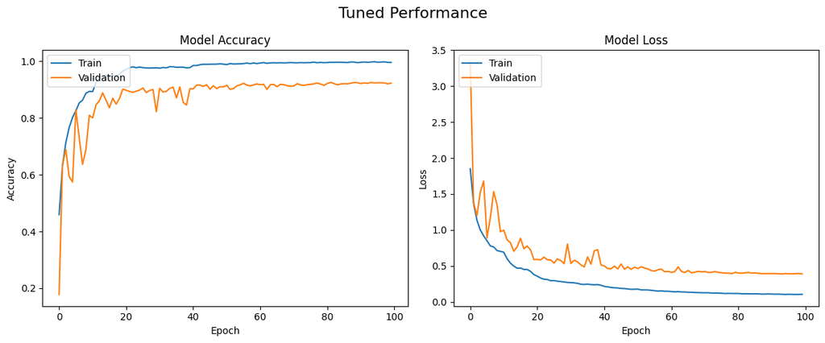

```python
fig, axs = plt.subplots(1, 2, figsize=(12, 5))

fig.suptitle('Tuned Performance', fontsize=16)

axs[0].plot(history.history['accuracy'])
axs[0].plot(history.history['val_accuracy'])
axs[0].set_title('Model Accuracy')
axs[0].set_ylabel('Accuracy')
axs[0].set_xlabel('Epoch')
axs[0].legend(['Train', 'Validation'], loc='upper left')

axs[1].plot(history.history['loss'])
axs[1].plot(history.history['val_loss'])
axs[1].set_title('Model Loss')
axs[1].set_ylabel('Loss')
axs[1].set_xlabel('Epoch')
axs[1].legend(['Train', 'Validation'], loc='upper left')

plt.tight_layout()
plt.show()
```

#### Observations:

- Much less noise
- Graph stabilises after 40 epochs

```python
model_name = "Tuned"

model_hist = {
    "Mean loss": np.mean(history.history['loss']),
    "Mean accuracy": np.mean(history.history['accuracy']),
    "Mean val_loss": np.mean(history.history['val_loss']),
    "Mean val_accuracy": np.mean(history.history['val_accuracy']),
}

model_df = pd.DataFrame([model_hist], index=[model_name])

perf_23_models = pd.concat([perf_23_models, model_df])

display(perf_23_models)
```

|  | Mean loss | Mean accuracy | Mean val_loss | Mean val_accuracy |
| --- | --- | --- | --- | --- |
| Original | 0.592896 | 0.930233 | 1.224521 | 0.784536 |
| Augmented | 0.641706 | 0.919871 | 1.070786 | 0.818741 |
| Tuned | 0.287633 | 0.962936 | 0.601703 | 0.877373 |

## 101 x 101

### Baseline for 101x101 (No Augmentation)

```python
X_batches, y_batches = zip(*ds_train_101.as_numpy_iterator())
X_train = np.vstack(X_batches)
y_train = np.hstack(y_batches)

X_train_101 = X_train.astype('float32') / 255.0
y_train_101 = to_categorical(y_train)

print("X_train shape:", X_train_101.shape)
print("y_train shape:", y_train_101.shape)
```

```
X_train shape: (7695, 101, 101, 1)
y_train shape: (7695, 11)
```

```python
X_batches, y_batches = zip(*ds_test_101.as_numpy_iterator())

X_test = np.vstack(X_batches)
y_test = np.hstack(y_batches)

X_test_101 = X_test.astype('float32') / 255.0

y_test_101 = to_categorical(y_test)

print("X_test shape:", X_test_101.shape)
print("y_test shape:", y_test_101.shape)
```

```
X_test shape: (2200, 101, 101, 1)
y_test shape: (2200, 11)
```

```python
X_batches, y_batches = zip(*ds_val_101.as_numpy_iterator())

X_val = np.vstack(X_batches)
y_val = np.hstack(y_batches)

X_val_101 = X_val.astype('float32') / 255.0

y_val_101 = to_categorical(y_val)

print("X_val shape:", X_val_101.shape)
print("y_val shape:", y_val_101.shape)
```

```
X_val shape: (2200, 101, 101, 1)
y_val shape: (2200, 11)
```

```python
OriginalModel101 = Sequential([
    Conv2D(32, (3, 3), padding='same', activation='relu', input_shape=(101, 101, 1), kernel_regularizer=regularizers.l2(0.001)),
    BatchNormalization(),
    MaxPooling2D(pool_size=2),

    Conv2D(64, (3, 3), padding='same', activation='relu', kernel_regularizer=regularizers.l2(0.001)),
    BatchNormalization(),
    MaxPooling2D(pool_size=2),

    Conv2D(128, (3, 3), padding='same', activation='relu', kernel_regularizer=regularizers.l2(0.001)),
    BatchNormalization(),
    MaxPooling2D(pool_size=2),

    Conv2D(256, (3, 3), padding='same', activation='relu', kernel_regularizer=regularizers.l2(0.001)),
    BatchNormalization(),
    MaxPooling2D(pool_size=2),

    GlobalAveragePooling2D(),
    Dropout(0.3),

    Dense(128, activation='relu', kernel_regularizer=regularizers.l2(0.001)),
    BatchNormalization(),
    Dropout(0.3),
    Dense(64, activation='relu', kernel_regularizer=regularizers.l2(0.001)),
    BatchNormalization(),
    Dropout(0.3),

    Dense(num_classes, activation='softmax')
])

OriginalModel101.compile(loss='categorical_crossentropy', optimizer='adam', metrics=['accuracy'])

checkpoint = ModelCheckpoint('./Part A checkpoints/original_model_weights_101.h5', monitor='val_accuracy', save_best_only=True, save_weights_only=True, mode='max', verbose=1)

history = OriginalModel101.fit(X_train_101, y_train_101, validation_data=(X_val_101, y_val_101), epochs=100, batch_size=64, callbacks=[checkpoint], verbose=1)

OriginalModel101.summary()
```

```
Epoch 1: val_accuracy improved from -inf to 0.09091, saving model to ./Part A checkpoints\original_model_weights_101.h5
Epoch 2: val_accuracy improved from 0.09091 to 0.09727, saving model to ./Part A checkpoints\original_model_weights_101.h5
Epoch 3: val_accuracy improved from 0.09727 to 0.09909, saving model to ./Part A checkpoints\original_model_weights_101.h5
Epoch 4: val_accuracy improved from 0.09909 to 0.22182, saving model to ./Part A checkpoints\original_model_weights_101.h5
Epoch 5: val_accuracy did not improve from 0.22182
Epoch 6: val_accuracy improved from 0.22182 to 0.51409, saving model to ./Part A checkpoints\original_model_weights_101.h5
Epoch 7: val_accuracy did not improve from 0.51409
Epoch 8: val_accuracy improved from 0.51409 to 0.55318, saving model to ./Part A checkpoints\original_model_weights_101.h5
Epoch 9: val_accuracy improved from 0.55318 to 0.66182, saving model to ./Part A checkpoints\original_model_weights_101.h5
Epoch 10: val_accuracy did not improve from 0.66182
Epoch 11: val_accuracy improved from 0.66182 to 0.85091, saving model to ./Part A checkpoints\original_model_weights_101.h5
Epoch 12: val_accuracy did not improve from 0.85091
Epoch 13: val_accuracy did not improve from 0.85091
Epoch 14: val_accuracy did not improve from 0.85091
Epoch 15: val_accuracy did not improve from 0.85091
Epoch 16: val_accuracy did not improve from 0.85091
Epoch 17: val_accuracy did not improve from 0.85091
Epoch 18: val_accuracy did not improve from 0.85091
Epoch 19: val_accuracy did not improve from 0.85091
Epoch 20: val_accuracy did not improve from 0.85091
Epoch 21: val_accuracy did not improve from 0.85091
Epoch 22: val_accuracy did not improve from 0.85091
Epoch 23: val_accuracy did not improve from 0.85091
Epoch 24: val_accuracy did not improve from 0.85091
Epoch 25: val_accuracy did not improve from 0.85091
Epoch 26: val_accuracy did not improve from 0.85091
Epoch 27: val_accuracy did not improve from 0.85091
Epoch 28: val_accuracy did not improve from 0.85091
Epoch 29: val_accuracy did not improve from 0.85091
Epoch 30: val_accuracy did not improve from 0.85091
Epoch 31: val_accuracy improved from 0.85091 to 0.90182, saving model to ./Part A checkpoints\original_model_weights_101.h5
Epoch 32: val_accuracy did not improve from 0.90182
Epoch 33: val_accuracy did not improve from 0.90182
Epoch 34: val_accuracy did not improve from 0.90182
Epoch 35: val_accuracy did not improve from 0.90182
Epoch 36: val_accuracy did not improve from 0.90182
Epoch 37: val_accuracy did not improve from 0.90182
Epoch 38: val_accuracy did not improve from 0.90182
Epoch 39: val_accuracy did not improve from 0.90182
Epoch 40: val_accuracy did not improve from 0.90182
```

[output cut: 107 more lines]

```

 dense_7 (Dense)             (None, 64)                8256

 batch_normalization_14 (Bat  (None, 64)               256
 chNormalization)

 dropout_5 (Dropout)         (None, 64)                0

 dense_8 (Dense)             (None, 11)                715

=================================================================
Total params: 432,395
Trainable params: 431,051
Non-trainable params: 1,344
_________________________________________________________________
```

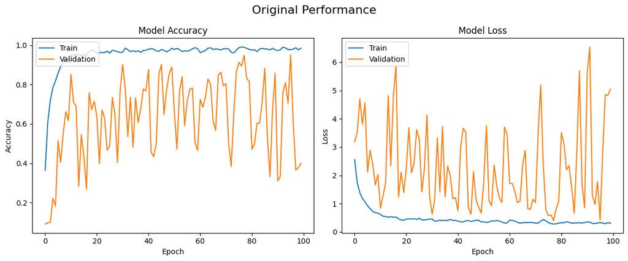

```python
fig, axs = plt.subplots(1, 2, figsize=(12, 5))

fig.suptitle('Original Performance', fontsize=16)

axs[0].plot(history.history['accuracy'])
axs[0].plot(history.history['val_accuracy'])
axs[0].set_title('Model Accuracy')
axs[0].set_ylabel('Accuracy')
axs[0].set_xlabel('Epoch')
axs[0].legend(['Train', 'Validation'], loc='upper left')

axs[1].plot(history.history['loss'])
axs[1].plot(history.history['val_loss'])
axs[1].set_title('Model Loss')
axs[1].set_ylabel('Loss')
axs[1].set_xlabel('Epoch')
axs[1].legend(['Train', 'Validation'], loc='upper left')

plt.tight_layout()
plt.show()
```

#### Observations:

- Quite a bit of noise
- Results not very good

```python
perf_101_models = pd.DataFrame()
```

```python
model_name = "Original"

model_hist = {
    "Mean loss": np.mean(history.history['loss']),
    "Mean accuracy": np.mean(history.history['accuracy']),
    "Mean val_loss": np.mean(history.history['val_loss']),
    "Mean val_accuracy": np.mean(history.history['val_accuracy']),
}

model_df = pd.DataFrame([model_hist], index=[model_name])

perf_101_models = pd.concat([perf_101_models, model_df])

display(perf_101_models)
```

|  | Mean loss | Mean accuracy | Mean val_loss | Mean val_accuracy |
| --- | --- | --- | --- | --- |
| Original | 0.460822 | 0.954073 | 2.299864 | 0.628186 |

### Balanced Data Augmentation

```python
X_batches, y_batches = zip(*ds_train_101.as_numpy_iterator())

X_train = np.vstack(X_batches)
y_train = np.hstack(y_batches)

X_train = X_train.astype('float32') / 255.0

class_counts = Counter(y_train)
max_count = max(class_counts.values())

datagen = ImageDataGenerator(
    rotation_range=10,
    width_shift_range=0.1,
    height_shift_range=0.1,
    zoom_range=0.15,
    shear_range=5,
    horizontal_flip=True,
    fill_mode='nearest'
)



X_balanced = []
y_balanced = []

for label in class_counts:
    idx = np.where(y_train == label)[0]
    X_class = X_train[idx]
    y_class = y_train[idx]

    X_balanced.extend(X_class)
    y_balanced.extend(y_class)

    num_to_generate = max_count - len(idx)
    if num_to_generate > 0:
        aug_iter = datagen.flow(X_class, y_class, batch_size=1)
        for _ in range(num_to_generate):
            x_aug, y_aug = next(aug_iter)
            X_balanced.append(x_aug[0])
            y_balanced.append(y_aug[0])

X_train_balanced_101 = np.array(X_balanced)
y_train_balanced_101 = to_categorical(np.array(y_balanced))
```

```python
print("Balanced X shape:", X_train_balanced_101.shape)
print("Balanced y shape:", y_train_balanced_101.shape)
```

```
Balanced X shape: (10505, 101, 101, 1)
Balanced y shape: (10505, 11)
```

```python
AugmentedModel101 = Sequential([
    Conv2D(32, (3, 3), padding='same', activation='relu', input_shape=(101, 101, 1), kernel_regularizer=regularizers.l2(0.001)),
    BatchNormalization(),
    MaxPooling2D(pool_size=2),

    Conv2D(64, (3, 3), padding='same', activation='relu', kernel_regularizer=regularizers.l2(0.001)),
    BatchNormalization(),
    MaxPooling2D(pool_size=2),

    Conv2D(128, (3, 3), padding='same', activation='relu', kernel_regularizer=regularizers.l2(0.001)),
    BatchNormalization(),
    MaxPooling2D(pool_size=2),

    Conv2D(256, (3, 3), padding='same', activation='relu', kernel_regularizer=regularizers.l2(0.001)),
    BatchNormalization(),
    MaxPooling2D(pool_size=2),

    GlobalAveragePooling2D(),
    Dropout(0.3),

    Dense(128, activation='relu', kernel_regularizer=regularizers.l2(0.001)),
    BatchNormalization(),
    Dropout(0.3),
    Dense(64, activation='relu', kernel_regularizer=regularizers.l2(0.001)),
    BatchNormalization(),
    Dropout(0.3),

    Dense(num_classes, activation='softmax')
])

AugmentedModel101.compile(loss='categorical_crossentropy', optimizer='adam', metrics=['accuracy'])

checkpoint = ModelCheckpoint('./Part A checkpoints/augmented_model_weights_101.h5', monitor='val_accuracy', save_best_only=True, save_weights_only=True, mode='max', verbose=1)

history = AugmentedModel101.fit(X_train_balanced_101, y_train_balanced_101, validation_data=(X_val_101, y_val_101), epochs=100, batch_size=64, callbacks=[checkpoint], verbose=1)

AugmentedModel101.summary()
```

```
Epoch 1: val_accuracy improved from -inf to 0.08591, saving model to ./Part A checkpoints\augmented_model_weights_101.h5
Epoch 2: val_accuracy improved from 0.08591 to 0.09045, saving model to ./Part A checkpoints\augmented_model_weights_101.h5
Epoch 3: val_accuracy improved from 0.09045 to 0.18273, saving model to ./Part A checkpoints\augmented_model_weights_101.h5
Epoch 4: val_accuracy improved from 0.18273 to 0.47045, saving model to ./Part A checkpoints\augmented_model_weights_101.h5
Epoch 5: val_accuracy improved from 0.47045 to 0.50818, saving model to ./Part A checkpoints\augmented_model_weights_101.h5
Epoch 6: val_accuracy did not improve from 0.50818
Epoch 7: val_accuracy did not improve from 0.50818
Epoch 8: val_accuracy did not improve from 0.50818
Epoch 9: val_accuracy improved from 0.50818 to 0.68773, saving model to ./Part A checkpoints\augmented_model_weights_101.h5
Epoch 10: val_accuracy did not improve from 0.68773
Epoch 11: val_accuracy did not improve from 0.68773
Epoch 12: val_accuracy improved from 0.68773 to 0.80864, saving model to ./Part A checkpoints\augmented_model_weights_101.h5
Epoch 13: val_accuracy did not improve from 0.80864
Epoch 14: val_accuracy improved from 0.80864 to 0.93227, saving model to ./Part A checkpoints\augmented_model_weights_101.h5
Epoch 15: val_accuracy did not improve from 0.93227
Epoch 16: val_accuracy did not improve from 0.93227
Epoch 17: val_accuracy did not improve from 0.93227
Epoch 18: val_accuracy did not improve from 0.93227
Epoch 19: val_accuracy did not improve from 0.93227
Epoch 20: val_accuracy did not improve from 0.93227
Epoch 21: val_accuracy did not improve from 0.93227
Epoch 22: val_accuracy did not improve from 0.93227
Epoch 23: val_accuracy did not improve from 0.93227
Epoch 24: val_accuracy did not improve from 0.93227
Epoch 25: val_accuracy did not improve from 0.93227
Epoch 26: val_accuracy did not improve from 0.93227
Epoch 27: val_accuracy did not improve from 0.93227
Epoch 28: val_accuracy did not improve from 0.93227
Epoch 29: val_accuracy did not improve from 0.93227
Epoch 30: val_accuracy did not improve from 0.93227
Epoch 31: val_accuracy did not improve from 0.93227
Epoch 32: val_accuracy did not improve from 0.93227
Epoch 33: val_accuracy did not improve from 0.93227
Epoch 34: val_accuracy did not improve from 0.93227
Epoch 35: val_accuracy did not improve from 0.93227
Epoch 36: val_accuracy did not improve from 0.93227
Epoch 37: val_accuracy did not improve from 0.93227
Epoch 38: val_accuracy did not improve from 0.93227
Epoch 39: val_accuracy did not improve from 0.93227
Epoch 40: val_accuracy did not improve from 0.93227
```

[output cut: 107 more lines]

```

 dense_10 (Dense)            (None, 64)                8256

 batch_normalization_20 (Bat  (None, 64)               256
 chNormalization)

 dropout_8 (Dropout)         (None, 64)                0

 dense_11 (Dense)            (None, 11)                715

=================================================================
Total params: 432,395
Trainable params: 431,051
Non-trainable params: 1,344
_________________________________________________________________
```

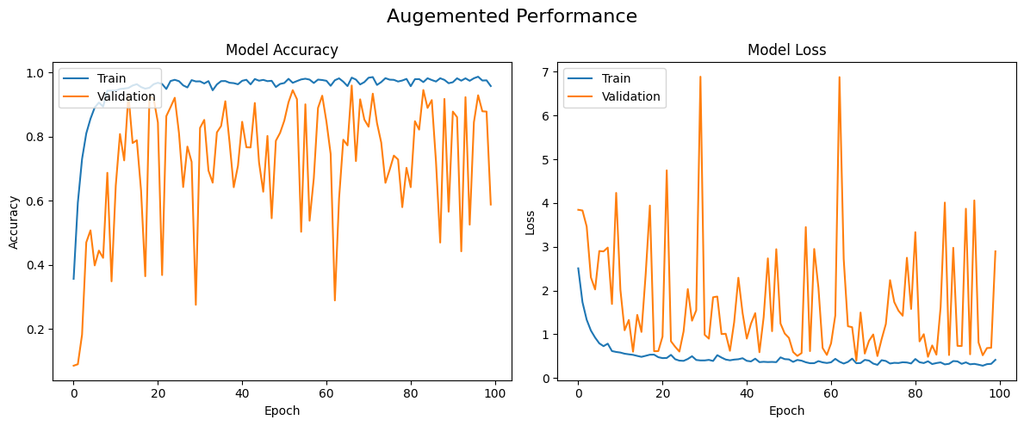

```python
fig, axs = plt.subplots(1, 2, figsize=(12, 5))

fig.suptitle('Augemented Performance', fontsize=16)

axs[0].plot(history.history['accuracy'])
axs[0].plot(history.history['val_accuracy'])
axs[0].set_title('Model Accuracy')
axs[0].set_ylabel('Accuracy')
axs[0].set_xlabel('Epoch')
axs[0].legend(['Train', 'Validation'], loc='upper left')

axs[1].plot(history.history['loss'])
axs[1].plot(history.history['val_loss'])
axs[1].set_title('Model Loss')
axs[1].set_ylabel('Loss')
axs[1].set_xlabel('Epoch')
axs[1].legend(['Train', 'Validation'], loc='upper left')

plt.tight_layout()
plt.show()
```

#### Observations:

- Validation Loss slightly improved
- Still a lot of noise, requires learning rate reducer to improve

```python
model_name = "Augmented"

model_hist = {
    "Mean loss": np.mean(history.history['loss']),
    "Mean accuracy": np.mean(history.history['accuracy']),
    "Mean val_loss": np.mean(history.history['val_loss']),
    "Mean val_accuracy": np.mean(history.history['val_accuracy']),
}

model_df = pd.DataFrame([model_hist], index=[model_name])

perf_101_models = pd.concat([perf_101_models, model_df])

display(perf_101_models)
```

|  | Mean loss | Mean accuracy | Mean val_loss | Mean val_accuracy |
| --- | --- | --- | --- | --- |
| Original | 0.460822 | 0.954073 | 2.299864 | 0.628186 |
| Augmented | 0.469260 | 0.952824 | 1.706500 | 0.721482 |

### Learning Rate Scheduler

```python
TunedModel101 = Sequential([
    Conv2D(32, (3, 3), padding='same', activation='relu', input_shape=(101, 101, 1), kernel_regularizer=regularizers.l2(0.001)),
    BatchNormalization(),
    MaxPooling2D(pool_size=2),

    Conv2D(64, (3, 3), padding='same', activation='relu', kernel_regularizer=regularizers.l2(0.001)),
    BatchNormalization(),
    MaxPooling2D(pool_size=2),

    Conv2D(128, (3, 3), padding='same', activation='relu', kernel_regularizer=regularizers.l2(0.001)),
    BatchNormalization(),
    MaxPooling2D(pool_size=2),

    Conv2D(256, (3, 3), padding='same', activation='relu', kernel_regularizer=regularizers.l2(0.001)),
    BatchNormalization(),
    MaxPooling2D(pool_size=2),

    GlobalAveragePooling2D(),
    Dropout(0.3),

    Dense(128, activation='relu', kernel_regularizer=regularizers.l2(0.001)),
    BatchNormalization(),
    Dropout(0.3),
    Dense(64, activation='relu', kernel_regularizer=regularizers.l2(0.001)),
    BatchNormalization(),
    Dropout(0.3),

    Dense(num_classes, activation='softmax')
])

TunedModel101.compile(loss='categorical_crossentropy', optimizer='adam', metrics=['accuracy'])

checkpoint = ModelCheckpoint('./Part A checkpoints/tuned_model_weights_101.h5', monitor='val_accuracy', save_best_only=True, save_weights_only=True, mode='max', verbose=1)

history = TunedModel101.fit(X_train_balanced_101, y_train_balanced_101, validation_data=(X_val_101, y_val_101), epochs=100, batch_size=64, callbacks=[checkpoint, reduce_lr], verbose=1)

TunedModel101.summary()
```

```
Epoch 1: val_accuracy improved from -inf to 0.12273, saving model to ./Part A checkpoints\tuned_model_weights_101.h5
Epoch 2: val_accuracy did not improve from 0.12273
Epoch 3: val_accuracy did not improve from 0.12273
Epoch 4: val_accuracy improved from 0.12273 to 0.43455, saving model to ./Part A checkpoints\tuned_model_weights_101.h5
Epoch 5: val_accuracy improved from 0.43455 to 0.52682, saving model to ./Part A checkpoints\tuned_model_weights_101.h5
Epoch 6: val_accuracy improved from 0.52682 to 0.70545, saving model to ./Part A checkpoints\tuned_model_weights_101.h5
Epoch 7: val_accuracy did not improve from 0.70545
Epoch 8: val_accuracy did not improve from 0.70545
Epoch 9: val_accuracy improved from 0.70545 to 0.89409, saving model to ./Part A checkpoints\tuned_model_weights_101.h5
Epoch 10: val_accuracy did not improve from 0.89409
Epoch 11: val_accuracy did not improve from 0.89409
Epoch 12: val_accuracy did not improve from 0.89409
Epoch 13: val_accuracy did not improve from 0.89409
Epoch 14: val_accuracy did not improve from 0.89409

Epoch 14: ReduceLROnPlateau reducing learning rate to 0.0005000000237487257.
Epoch 15: val_accuracy did not improve from 0.89409
Epoch 16: val_accuracy improved from 0.89409 to 0.95545, saving model to ./Part A checkpoints\tuned_model_weights_101.h5
Epoch 17: val_accuracy did not improve from 0.95545
Epoch 18: val_accuracy did not improve from 0.95545
Epoch 19: val_accuracy did not improve from 0.95545
Epoch 20: val_accuracy did not improve from 0.95545
Epoch 21: val_accuracy did not improve from 0.95545

Epoch 21: ReduceLROnPlateau reducing learning rate to 0.0002500000118743628.
Epoch 22: val_accuracy improved from 0.95545 to 0.96591, saving model to ./Part A checkpoints\tuned_model_weights_101.h5
Epoch 23: val_accuracy improved from 0.96591 to 0.97773, saving model to ./Part A checkpoints\tuned_model_weights_101.h5
Epoch 24: val_accuracy improved from 0.97773 to 0.98727, saving model to ./Part A checkpoints\tuned_model_weights_101.h5
Epoch 25: val_accuracy did not improve from 0.98727
Epoch 26: val_accuracy did not improve from 0.98727
Epoch 27: val_accuracy improved from 0.98727 to 0.98818, saving model to ./Part A checkpoints\tuned_model_weights_101.h5
Epoch 28: val_accuracy did not improve from 0.98818
Epoch 29: val_accuracy did not improve from 0.98818
Epoch 30: val_accuracy did not improve from 0.98818
Epoch 31: val_accuracy did not improve from 0.98818
Epoch 32: val_accuracy did not improve from 0.98818
Epoch 33: val_accuracy did not improve from 0.98818
Epoch 34: val_accuracy did not improve from 0.98818
Epoch 35: val_accuracy did not improve from 0.98818
Epoch 36: val_accuracy did not improve from 0.98818
```

[output cut: 119 more lines]

```

 dense_13 (Dense)            (None, 64)                8256

 batch_normalization_26 (Bat  (None, 64)               256
 chNormalization)

 dropout_11 (Dropout)        (None, 64)                0

 dense_14 (Dense)            (None, 11)                715

=================================================================
Total params: 432,395
Trainable params: 431,051
Non-trainable params: 1,344
_________________________________________________________________
```

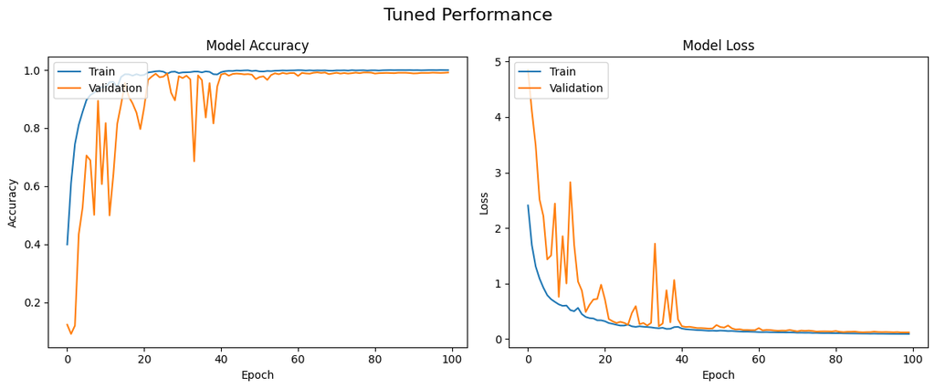

```python
fig, axs = plt.subplots(1, 2, figsize=(12, 5))

fig.suptitle('Tuned Performance', fontsize=16)

axs[0].plot(history.history['accuracy'])
axs[0].plot(history.history['val_accuracy'])
axs[0].set_title('Model Accuracy')
axs[0].set_ylabel('Accuracy')
axs[0].set_xlabel('Epoch')
axs[0].legend(['Train', 'Validation'], loc='upper left')

axs[1].plot(history.history['loss'])
axs[1].plot(history.history['val_loss'])
axs[1].set_title('Model Loss')
axs[1].set_ylabel('Loss')
axs[1].set_xlabel('Epoch')
axs[1].legend(['Train', 'Validation'], loc='upper left')

plt.tight_layout()
plt.show()
```

#### Observations:

- Much less noise
- Graph stabilizes after 40 epochs
- Validation accuracy and loss are very good

```python
model_name = "Tuned"

model_hist = {
    "Mean loss": np.mean(history.history['loss']),
    "Mean accuracy": np.mean(history.history['accuracy']),
    "Mean val_loss": np.mean(history.history['val_loss']),
    "Mean val_accuracy": np.mean(history.history['val_accuracy']),
}

model_df = pd.DataFrame([model_hist], index=[model_name])

perf_101_models = pd.concat([perf_101_models, model_df])

display(perf_101_models)
```

|  | Mean loss | Mean accuracy | Mean val_loss | Mean val_accuracy |
| --- | --- | --- | --- | --- |
| Original | 0.460822 | 0.954073 | 2.299864 | 0.628186 |
| Augmented | 0.469260 | 0.952824 | 1.706500 | 0.721482 |
| Tuned | 0.271823 | 0.974585 | 0.551553 | 0.906327 |

### Model Evaluation

```python
print("23X23 Models")
display(perf_23_models)
print("101X101 Models")
display(perf_101_models)
```

```
23X23 Models
```

|  | Mean loss | Mean accuracy | Mean val_loss | Mean val_accuracy |
| --- | --- | --- | --- | --- |
| Original | 0.592896 | 0.930233 | 1.224521 | 0.784536 |
| Augmented | 0.641706 | 0.919871 | 1.070786 | 0.818741 |
| Tuned | 0.287633 | 0.962936 | 0.601703 | 0.877373 |

```
101X101 Models
```

|  | Mean loss | Mean accuracy | Mean val_loss | Mean val_accuracy |
| --- | --- | --- | --- | --- |
| Original | 0.460822 | 0.954073 | 2.299864 | 0.628186 |
| Augmented | 0.469260 | 0.952824 | 1.706500 | 0.721482 |
| Tuned | 0.271823 | 0.974585 | 0.551553 | 0.906327 |

#### We can see that the tuned models were the best, so we will use those to form our conclusions

```python
print("Evaluation for 23x23 Model")

TunedModel23.load_weights('./Part A checkpoints/tuned_model_weights_23.h5')

TunedModel23.compile(loss='categorical_crossentropy', optimizer='adam', metrics=['accuracy'])

scores_23 = TunedModel23.evaluate(X_test_23, y_test_23, verbose=0)
print("Test Loss: %.4f" % scores_23[0])
print("Test Accuracy: %.2f%%" % (scores_23[1] * 100))
print("Test Error: %.2f%%" % (100 - scores_23[1] * 100))
```

```
Evaluation for 23x23 Model
Test Loss: 0.3472
Test Accuracy: 93.05%
Test Error: 6.95%
```

```python
print("Evaluation for 101x101 Model")

TunedModel101.load_weights('./Part A checkpoints/tuned_model_weights_101.h5')

TunedModel101.compile(loss='categorical_crossentropy', optimizer='adam', metrics=['accuracy'])

scores_101 = TunedModel101.evaluate(X_test_101, y_test_101, verbose=0)

print("Test Loss: %.4f" % scores_101[0])
print("Test Accuracy: %.2f%%" % (scores_101[1] * 100))
print("Test Error: %.2f%%" % (100 - scores_101[1] * 100))
```

```
Evaluation for 101x101 Model
Test Loss: 0.1456
Test Accuracy: 99.05%
Test Error: 0.95%
```

#### Classification Report of 23 by 23 Model

```python
y_test_int_23 = np.argmax(y_test_23, axis=1)

y_pred_23 = TunedModel23.predict(X_test_23)

report23 = classification_report(
    y_test_int_23,
    np.argmax(y_pred_23, axis=1),
    target_names=class_names
)

print("Classification Report for 23x23 Model:")
print(report23)
```

```
Classification Report for 23x23 Model:
                           precision    recall  f1-score   support

                     Bean       0.93      0.95      0.94       200
             Bitter_Gourd       0.96      0.92      0.94       200
                  Brinjal       0.92      0.96      0.94       200
                  Cabbage       0.95      0.92      0.93       200
                 Capsicum       0.98      0.95      0.97       200
        Carrot and Radish       0.98      0.95      0.96       200
 Cauliflower and Broccoli       0.87      0.84      0.86       200
Cucumber and Bottle_Gourd       0.95      0.96      0.95       200
                   Potato       0.95      0.94      0.94       200
                  Pumpkin       0.92      0.93      0.93       200
                   Tomato       0.83      0.91      0.87       200

                 accuracy                           0.93      2200
                macro avg       0.93      0.93      0.93      2200
             weighted avg       0.93      0.93      0.93      2200
```

#### Classification Report of 101 by 101 Model

```python
y_test_int_101 = np.argmax(y_test_101, axis=1)

y_pred_101 = TunedModel101.predict(X_test_101)

report101 = classification_report(
    y_test_int_101,
    np.argmax(y_pred_101, axis=1),
    target_names=class_names
)

print("Classification Report for 101x101 Model:")
print(report101)
```

```
Classification Report for 101x101 Model:
                           precision    recall  f1-score   support

                     Bean       0.99      0.99      0.99       200
             Bitter_Gourd       1.00      0.99      1.00       200
                  Brinjal       0.99      0.99      0.99       200
                  Cabbage       0.98      0.98      0.98       200
                 Capsicum       0.99      0.99      0.99       200
        Carrot and Radish       0.99      0.99      0.99       200
 Cauliflower and Broccoli       0.99      0.97      0.98       200
Cucumber and Bottle_Gourd       0.98      0.99      0.99       200
                   Potato       0.99      0.99      0.99       200
                  Pumpkin       0.99      0.99      0.99       200
                   Tomato       0.98      1.00      0.99       200

                 accuracy                           0.99      2200
                macro avg       0.99      0.99      0.99      2200
             weighted avg       0.99      0.99      0.99      2200
```

#### Observations:

- From the classification report, we can see that our 101x101 model has performed very well with a precision, recall and f1-score of all around 0.99
- The scores for each vegetable are also very close to one another which shows that our model has learned to generalise well for all the different vegetables
- Our 23x23 model has also performed quite well but there is slightly more variation like how Capsicum has a 98% precision while Tomato only has 83%
- Overall both models have performed quite well with the 23x23 model having a weighted average of 93.05% and the 101x101 model having a weighted average of 99.05%

#### Final Conclusion

- Overall, its seems that the 101x101 model has a better performance compared to the 23x23 model in terms of both accuracy and loss. However, the improvement in the performance is not that much and the 23x23 model already has a very good performance on its on
- Another thing to note is that the 101x101 model took significantly longer to train compared to the 23x23 model in terms of both running the model and for the data augmentation where augmenting the 101x101 model took much longer compared to the 23x23 model.
- This means that if the perfect model is not needed and time is a huge concern, it would be better to go with a smaller image size like the 23x23 model since training it would be much shorter. However, if the goal is to have the best model possible, it would make more sense to use an even larger image size like the 101x101 model though in some cases like this one, the improvement won't be very drastic

### Saving best model weights

```python
TunedModel23.save_weights('./Part A Best Weights/best_model_weights_23.h5')
```

```python
TunedModel101.save_weights('./Part A Best Weights/best_model_weights_101.h5')
```